# Introduction of Cirq

@Cirq Bootcamp 2021.06.26

今井 良輔 (QunaSys inc.)

*This notebook partially based on [cirq tutorial](https://quantumai.google/cirq/tutorials/educators/intro)*

# アウトライン

- 量子コンピュータの基礎
- Python の基礎
- Cirq 入門
- NISQアルゴリズムの例
  - 変分アルゴリズム

# 量子コンピュータの基礎

## 古典コンピュータとは？

**古典**コンピュータ (classical computer)

= ふつうの、従来型のコンピュータ

≠ 量子コンピュータ

(2021年現在、日常的に身の回りにあるコンピュータ)

古典コンピュータの中で起きていることをイメージしてみよう

- 電流のオンオフで情報をあらわす
- 情報の保持と操作
  - 保持 … キャパシタ、フリップフロップ回路、など
  - 操作 … トランジスタ（電流を流すスイッチの役割）

オンオフで複雑な情報を表す方法

- {オン, オフ} を ${0, 1}$ の2値にマップする
- 数 5 (10進法) -> `0101` (2進法)
- 文字 "A" -> 65 (ASCII, 10進法) -> `0100 0001` (2進法)
- 情報を $0, 1$ の列で表す
  - 一桁の $0, 1$ を**ビット**という。情報の最小単位。
  - 1つのビットは $0, 1$ のどちらかの状態を必ず取る

実際にはこれらの振る舞いは抽象化されて、プログラミング言語で制御する。 たとえば、

```
a = 5
// メモリ上に領域`a`を確保して、そこに 5 (= 0101) を入れておく
b = "A"
// メモリ上に領域`b`を確保して、そこに A (= 0100 0001) を入れておく
```

## 量子コンピュータとは？

**量子コンピュータ = 量子論の性質を活用して計算を行うコンピュータ**

量子の性質 … 重ね合わせ、量子もつれ **非日常な性質**

量子コンピュータも（古典コンピュータ）と同様にビットの集まりとして考える。

**ただし、ビットが量子の性質を持つ -> 量子ビット**

## 量子ビットの性質

**“量子”ビット** = 量子の世界の情報の最小単位 = qubit

量子の状態はベクトルとして表される

$$ |\psi\rangle = \alpha |0\rangle + \beta |1\rangle \quad (\text{$\alpha, \beta$ は $|\alpha|^2 + |\beta|^2 = 1$を満たす複素数}) $$

(2次元上の点 $\vec{v} = v_x \vec{e}_x + v_y \vec{e}_y$ と数式としては同じ意味)

係数を集めてきて（縦）ベクトルとして書いても良い

$$ \left( \begin{array}{c} \alpha \\ \beta \end{array} \right) $$

いくつかの呼び方：状態、量子状態、状態ベクトル、波動関数…

## 量子状態の解釈

$$ |\psi\rangle = \alpha |0\rangle + \beta |1\rangle \quad (\text{$\alpha, \beta$ は $|\alpha|^2 + |\beta|^2 = 1$を満たす複素数}) $$

は

$$ |\alpha|^2 \dots \text{量子ビットを測定したときに 0 となる確率} \\ |\beta|^2 \dots \text{量子ビットを測定したときに 1 となる確率} $$

のような特徴を持つ状態

## 量子ビットの測定

量子ビットの情報は**測定**という操作を通じて得ることができる。

- 測定で得られるもの：
  - $0, 1$ の値
  - $\alpha, \beta$ の値を直接調べることはできない！

### (例)

量子状態

$$ |\psi\rangle = \frac{3}{5} |0\rangle + \frac{4}{5} |1\rangle $$

を測定すると $$ \text{確率 $\big(\frac{3}{5}\big)^2 = \frac{9}{25}$ で $0$ が観測される} \\ \text{確率 $\big(\frac{4}{5}\big)^2 = \frac{16}{25}$ で $1$ が観測される} $$

実際に量子コンピュータで繰り返し量子ビットを測定すると、 $$ 0, 1, 0, 0, 1, 0, 1, 1, 1, 0, ... $$ のような列が観測される

## 複数の量子ビットの状態

2量子ビットの状態は

$$ |\psi\rangle = c_{00} |00\rangle + c_{01} |01\rangle + c_{10} |10\rangle + c_{11} |11\rangle $$

3量子ビットの状態は

$$ \begin{align*} |\psi\rangle &= c_{000} |000\rangle + c_{001} |001\rangle + c_{010} |010\rangle + c_{011} |011\rangle \\ & \quad + c_{100} |100\rangle + c_{101} |101\rangle + c_{110} |110\rangle + c_{111} |111\rangle \end{align*} $$

一般にn量子ビットの状態は

$$ \begin{align*} |\psi\rangle = \sum_{i=0}^{2^n-1} c_i |i\rangle \end{align*} $$

## 量子ビットに対する操作：量子ゲート

量子ビットに対する操作を**ゲート**と呼ぶ。

ゲートは量子ビットの状態を別の状態に変化させる。

- 単一量子ビットに作用するゲートの例
  - **X ゲート** NOT演算に相当 $$ X |0\rangle = |1\rangle \\ X |1\rangle = |0\rangle $$ 行列表示は $$ \begin{pmatrix} 0 & 1 \\ 1 & 0 \end{pmatrix} $$
- (例の続き)
  - **Z ゲート** 1状態だけに$(-1)$の位相がつく $$ Z |0\rangle = |0\rangle \\ Z |1\rangle = -|1\rangle $$ 行列表示は $$ \begin{pmatrix} 1 & 0 \\ 0 & -1 \end{pmatrix} $$
  - **H ゲート** アダマール(Hadamard)ゲート $$ H |0\rangle = \frac{1}{\sqrt{2}} |0\rangle + \frac{1}{\sqrt{2}} |1\rangle\\ H |1\rangle = \frac{1}{\sqrt{2}} |0\rangle - \frac{1}{\sqrt{2}} |1\rangle $$ $$ \frac{1}{\sqrt{2}} \begin{pmatrix} 1 & 1 \\ 1 & -1 \end{pmatrix} $$

複数量子ビットに作用するゲートもある

- Controlled-NOT (CNOT) ゲート $\textrm{CNOT}_{i,j}$

  $i$番目の量子ビットが1の場合に限り、$j$番目の量子ビットにNOTを作用させる。

$$ \textrm{CNOT}_{0,1} |00> = |00> \\ \textrm{CNOT}_{0,1} |01> = |01> \\ $$

$$ \textrm{CNOT}_{0,1} |10> = |11> \\ \textrm{CNOT}_{0,1} |11> = |10> $$

  $i$番目の量子ビットが1の場合に限り、$j$番目の量子ビットにZを作用させる。

$$ \textrm{CZ}_{0,1} |00> = |00> \\ \textrm{CZ}_{0,1} |01> = |01> \\ $$

$$ \textrm{CZ}_{0,1} |10> = |10> \\ \textrm{CZ}_{0,1} |11> = -|11> $$

## 量子情報処理の設計図 = 量子回路図

量子ビットにどのようなゲートを作用させるかを決める = 量子コンピュータに対するプログラミング

設計図 = 量子回路図の例

[figure not shown]

- 横線がそれぞれ１つの量子ビットに対応
- 回路図にある箱や縦線が、量子ゲートを表す
  - 上の例では Hゲート と CNOTゲート
- 右のメーターは測定することを表す
- 作用する順番は左が先

## 量子コンピュータと誤り

- コンピュータは外的要因（ノイズ）で誤り（エラー）が生じる
  - 外的要因 … 電磁波、熱、…
- 誤りがあるなら訂正すればよい
  - 古典コンピュータでは普段から行われている
    - 素朴なイメージ：多数決
  - 量子コンピュータでも訂正する方法は知られている
    - ただし大量の量子ビットが必要 10^6個
      - 実現は10年後くらい？

### Noisy Intermediate-Scale Quantum device (NISQ)

- 数百個程度の量子ビットからなる量子コンピュータ
  - 2018年に J. Preskill が提唱 ([論文](https://quantum-journal.org/papers/q-2018-08-06-79/))
  - 数年以内には実現されそう
- エラーの訂正ができない = Noisy
- 実行できるアルゴリズムに制限
  - 量子ビット数が少ない
  - 長い回路は実行できない（エラーが蓄積してしまうため）

### connectivity による量子ゲートの制約

- 2量子ビットゲートが作用できるのは、物理的に接続されている量子ビット間のみ
- 接続していない量子ビット間に作用をさせたければ、SWAP ゲートにより2量子ビットの情報を入れ替える必要がある
  - 2量子ビットゲートはエラーレートが比較的高いため、NISQでは可能な限りその数を減らしたい
- 1量子ビットゲートには制約なし

Google の72量子ビットの量子プロセッサ「Bristlecone」

[figure not shown]

右の模式図中の"X"がそれぞれ量子ビットとなっている。隣り合っている量子ビット同士は接続されている。

実際にどのようなアルゴリズムが実行されるかは、後ほどCirqと一緒に紹介します

# Pythonの基礎

- ある程度のプログラミングの経験は前提
- Pythonの一見わかりづらい機能の説明に留めます
  - Iterator
  - Generator

## Iterator

- forループが実行されるときなどに使われます。
  - 最も単純な iterator の例はリストです。
- オブジェクトからイテレータが生成できる場合、そのオブジェクトは *iterable* と呼ばれます。

```python
the_list = ['quantum', 'computing', 'cirq', 2021]

print(the_list)
```

```
['quantum', 'computing', 'cirq', 2021]
```

```python
the_iterator = iter(the_list)

# iterator は next() で次の要素を取得できる
print(next(the_iterator))
print(next(the_iterator))
print(next(the_iterator))
print(next(the_iterator))
```

```
quantum
computing
cirq
2021
```

```python
the_iterator = iter(the_list)

for x in the_iterator:
    print(x)
```

```
quantum
computing
cirq
2021
```

## Generator

例からはじめましょう。これが generator の定義です。

```python
def countdown_generator():
    yield 3
    yield 2
    yield 1
    yield "fire!"
```

```python
# generator は iterator を返します
iterator = countdown_generator()
for i in iterator:
    print(i)
```

```
3
2
1
fire!
```

generatorの便利な使い方 1

```python
def counter_generator():
    """長さ無限のiterator"""
    i = 0
    while True:
        yield i
        i += 1

counter = counter_generator()
print(next(counter))
print(next(counter))
print(next(counter))
```

```
0
1
2
```

generatorの便利な使い方 2

```python
def 重い処理():
    pass

# 重い処理を先に実行しておく
list_with_heavy_processing = [重い処理(), 重い処理(), 重い処理()]

# 必要なタイミングで重い処理が実行される -> 遅延評価
def generator_with_重い処理(i):
    yield 重い処理()
    yield 重い処理()
    yield 重い処理()
```

# cirq 入門

## Cirq とは

An open source framework for programming quantum computers

- Python ライブラリ
- 量子回路の作成・最適化・シミュレーション・量子コンピュータでの実行ができる
- NISQ に合わせた抽象化がされている
  - ハードウェアの特性を考慮した制御が可能

```python
# cirqのインストール/インポート

try:
    import cirq
except ImportError:
    print("installing cirq...")
    !pip install --quiet cirq
    print("installed cirq.")
    import cirq

import matplotlib.pyplot as plt
import numpy as np
```

## Qubits, Operations, Moments and Circuits

量子回路は`Circuit`オブジェクトで表現される

- `Circuit`は `Moment`の集まり
- `Moment`は、（抽象的に）同じタイミングの中で動作する`Operation`の集まり
- `Operation`とは、量子ビットの特定のサブセットに対する作用
  - 最も一般的なタイプの`Operation`は、複数の量子ビットに適用される`Gate`である（`GateOperation`）。
- 回路の量子ビットはoperationsによって暗黙的に定義される

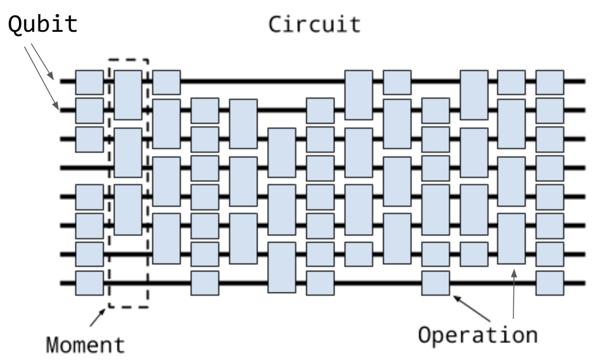

### 量子ビットを準備する

```python
a = cirq.NamedQubit("a")
b = cirq.NamedQubit("b")
c = cirq.NamedQubit("c")
```

```python
# わかりやすい名前を付けてもよい
q0 = cirq.NamedQubit('source')
q1 = cirq.NamedQubit('target')
```

```python
# 一列に並んだ量子ビット
q0, q1, q2 = cirq.LineQubit.range(3)
```

```python
# 正方格子上に並んだ量子ビット
# (0,0) から (3,3) の16ビットが作られる
qubits = cirq.GridQubit.square(4)
qubits
```

```
[cirq.GridQubit(0, 0),
 cirq.GridQubit(0, 1),
 cirq.GridQubit(0, 2),
 cirq.GridQubit(0, 3),
 cirq.GridQubit(1, 0),
 cirq.GridQubit(1, 1),
 cirq.GridQubit(1, 2),
 cirq.GridQubit(1, 3),
 cirq.GridQubit(2, 0),
 cirq.GridQubit(2, 1),
 cirq.GridQubit(2, 2),
 cirq.GridQubit(2, 3),
 cirq.GridQubit(3, 0),
 cirq.GridQubit(3, 1),
 cirq.GridQubit(3, 2),
 cirq.GridQubit(3, 3)]
```

```python
import cirq_google
# 実Deviceの
print(cirq_google.Foxtail)
```

```
(0, 0)───(0, 1)───(0, 2)───(0, 3)───(0, 4)───(0, 5)───(0, 6)───(0, 7)───(0, 8)───(0, 9)───(0, 10)
│        │        │        │        │        │        │        │        │        │        │
│        │        │        │        │        │        │        │        │        │        │
(1, 0)───(1, 1)───(1, 2)───(1, 3)───(1, 4)───(1, 5)───(1, 6)───(1, 7)───(1, 8)───(1, 9)───(1, 10)
```

### `Circuit` を作る

```python
"""Creating a circuit."""
# 量子ビットの定義
a = cirq.NamedQubit("a")
b = cirq.NamedQubit("b")
c = cirq.NamedQubit("c")

# ゲートの列
ops = [cirq.H(a), cirq.H(b), cirq.CNOT(b, c), cirq.H(b)]

# cirq.Circuit にiteratorを渡すと回路が作られる
circuit = cirq.Circuit(ops)
print("Circuit:\n")
print(circuit)
```

```
Circuit:

a: ───H───────────

b: ───H───@───H───
          │
c: ───────X───────
```

`Circuit`の詳細を表示してみる：

```python
"""Print out the moments in a circuit."""
print("Circuit:\n")
print(circuit)

# Inspecting individual moments.
print("\nMoments in the circuit:\n")
for i, moment in enumerate(circuit):
    print('Moment {}: \n{}'.format(i, moment))
```

```
Circuit:

a: ───H───────────

b: ───H───@───H───
          │
c: ───────X───────

Moments in the circuit:

Moment 0:
  ╷ None
╶─┼──────
a │ H
  │
b │ H
  │
Moment 1:
  ╷ None
╶─┼──────
b │ @
  │ │
c │ X
  │
Moment 2:
  ╷ None
╶─┼──────
b │ H
  │
```

## 回路のシミュレーション

次の量子回路図をシミュレーションしてみましょう

[figure not shown]

どういうコードで作れるかイメージできますか？

```python
def basic_circuit(measure=True):
    yield cirq.H(a)
    yield cirq.CNOT(a, b)
    if measure:
        yield cirq.measure(a)

circuit = cirq.Circuit(basic_circuit())
print(circuit)
```

```
a: ───H───@───M───
          │
b: ───────X───────
```

回路シミュレーションの2つの方法

```
simulator = cirq.Simulator()
simulator.simulate(circuit)
#もしくは
simulator.run(circuit)
```

- simulate メソッド

> 波動関数を用いて回路をシミュレートします。この場合、結果の波動関数に直接アクセスして見ることができます。 デバッグ、学習、および回路がどのように機能するかを理解するのに役立ちます。
- run メソッド

> 実際の量子デバイスを使用する場合と同じような、サンプリング方式で回路をシミュレートします。出力として測定結果のビット文字列のみを返します。波動関数にはアクセスできません。

```python
# simulate メソッドを使う場合
circuit = cirq.Circuit(basic_circuit(measure=False))
simulator = cirq.Simulator()
result = simulator.simulate(circuit)

print("\nDirac notation:")
print(result.dirac_notation())

print("State vector:")
print(np.around(result.final_state_vector, 3))
```

```
Dirac notation:
0.71|00⟩ + 0.71|11⟩
State vector:
[ 0.707+0.j  0.   +0.j -0.   +0.j  0.707+0.j]
```

```python
# run メソッドを使う場合
circuit = cirq.Circuit(basic_circuit())
simulator = cirq.Simulator()
result = simulator.run(circuit)
print("Measurement results:")
print(result) # 結果は実行する度に変わる
```

```
Measurement results:
a=0
```

```python
# 10回繰り返してみる
circuit = cirq.Circuit(basic_circuit())
simulator = cirq.Simulator()
result = simulator.run(circuit, repetitions=10)
print(result) # 結果は実行する度に変わる
```

```
a=1011111111
```

```python
circuit = cirq.Circuit(basic_circuit())
result = simulator.run(circuit, repetitions=1000)
print(result)
print()
print(result.histogram(key="a"))
```

```
a=010010010100110111101001001001101010010000010100010010010011…

Counter({0: 505, 1: 495})
```

## パラメータをもつゲート（Parametrized gates）

確定した値を持つ回路ゲートのほかに、Cirqは`sympy`による`Symbol`を持つパラメータを持つゲートもサポートしています。 パラメータは `sympy.Symbol('x')` のようなプレースホルダーで与えられ、*実行時*に解決されます。

```python
"""Define a circuit with parameterized gates."""
# Import sympy for parameterized values.
import sympy as sp

# Get qubits to use in the circuit.
a = cirq.NamedQubit("a")
b = cirq.NamedQubit("b")

# Define a parameterized value.
val = sp.Symbol("s")

# Create a circuit.
circuit = cirq.Circuit(cirq.X.on(a) ** val, cirq.X.on(b) ** val)

# Display it.
print("Circuit with parameterized gates:\n")
print(circuit)
```

```
Circuit with parameterized gates:

a: ───X^s───

b: ───X^s───
```

```python
print(circuit)
print()

"""Simulate the circuit at multiple parameter values."""
simulator = cirq.Simulator()

# Simulate the circuit for several values of the parameter.
num_params = 5
for y in range(num_params):
    result = simulator.simulate(circuit, param_resolver={"s": y / 4.0})
    print("s={}: {}\n".format(y, np.around(result.final_state_vector, 2)))
```

```
a: ───X^s───

b: ───X^s───

s=0: [1.+0.j 0.+0.j 0.+0.j 0.+0.j]

s=1: [ 0.6 +0.6j   0.25-0.25j  0.25-0.25j -0.1 -0.1j ]

s=2: [0. +0.5j 0.5+0.j  0.5+0.j  0. -0.5j]

s=3: [-0.1 +0.1j   0.25+0.25j  0.25+0.25j  0.6 -0.6j ]

s=4: [0.+0.j 0.+0.j 0.+0.j 1.+0.j]
```

## ノイズの影響を取り入れたシミュレーション

Cirqでは、ユニタリー・ゲートを用いた回路のほかに、ノイズの影響を取り入れることもできます。 これは、実際のハードウェア上で実行したときに起こることをモデル化する際に便利です。

Cirqは現在、ノイズの*operator sum representations*の文脈に適合するノイズをサポートしています（quantum dyanamical maps, superoperators, etc）。 この形式では、密度行列の変化を次のようにモデル化します。

$$ \rho \rightarrow \sum_k A_k \rho A_k^\dagger $$

ここで$A_k$は*Kraus演算子*です。 これらの演算子は必ずしもユニタリーではなく、次のような性質を持っています。

$$ \sum_k A_k^\dagger A_k = I . $$

ノイズ演算子の例としては、1量子ビットのdepolarizing チャネルがあります。

$$ \rho \rightarrow (1-p) \rho + \frac{p}{3} (X \rho X + Y \rho Y + Z \rho Z) . $$

Cirqでは、このようなチャンネルを定義し、量子回路で使用することができます。

```python
"""Create a circuit with a depolarizing channel."""
circuit = cirq.Circuit(cirq.depolarize(0.2)(a), cirq.measure(a))
print(circuit)
```

```
a: ───D(0.2)───M───
```

Cirqには密度行列のシミュレーションもサポートしており、同じ `run` および `simulate` タイプのメソッドを備えています。

```python
"""Example of simulating a noisy circuit with the density matrix simulator."""
# Circuit to simulate.
circuit = cirq.Circuit(cirq.depolarize(0.2)(a))
print('Circuit:\n{}\n'.format(circuit))

# Get the density matrix simulator.
simulator = cirq.DensityMatrixSimulator()

# Simulate the circuit and get the final density matrix.
matrix = simulator.simulate(circuit).final_density_matrix
print('Final density matrix:\n{}'.format(matrix))
```

```
Circuit:
a: ───D(0.2)───

Final density matrix:
[[0.8666666 +0.j 0.        +0.j]
 [0.        +0.j 0.13333333+0.j]]
```

# NISQ アルゴリズムを動かしてみる

- [Variational Quantum Algorithm](https://quantumai.google/cirq/tutorials/variational_algorithm)

# おまけの話題

## cirq-qulacs

世界最速量子計算シミュレータ qulacs を Cirq のシミュレーターバックエンドとして使用できるライブラリ

[GitHub](https://github.com/qulacs/cirq-qulacs)

## Quantum Native Dojo

[Quantum Native Dojo!](https://dojo.qulacs.org/ja/latest/)

量子コンピュータについて勉強したいと思っている方のために作られた自習教材

- 量子情報の基礎
- 量子アルゴリズム入門
- 量子ダイナミクスシミュレーション
- 量子変分回路に基づくアルゴリズム
- 量子化学計算
- 量子位相推定アルゴリズムの発展
- 量子探索アルゴリズム
- 量子誤り訂正

ありがとうございました！